# Part I - Ford GoBike System Data

## Introduction

Dataset: Ford GoBike trip data (February 2019)

Brief: This dataset contains individual trip records from the Ford GoBike (Bay Wheels) bike-share system for February 2019. Each row represents a trip and includes start and end timestamps, station names/IDs, user type (Subscriber or Customer), and bike ID. The data covers a full calendar month and is suitable for exploring temporal patterns (hour of day, day of week), user behavior differences, and trip duration distributions.

## Preliminary Wrangling

```python
# import all packages and set plots to be embedded inline
import numpy as np
import pandas as pd
import matplotlib.pyplot as plt
import seaborn as sns
```

```python
# Display settings
%matplotlib inline
sns.set(style='whitegrid')


# Path to dataset (already uploaded in the workspace)
DATA_PATH = '201902-fordgobike-tripdata.csv'


# Load dataset
df = pd.read_csv(DATA_PATH)


# Quick peek
print('Rows, cols:', df.shape)
df.info()
df.head()
```

```
Rows, cols: (183412, 16)
<class 'pandas.core.frame.DataFrame'>
RangeIndex: 183412 entries, 0 to 183411
Data columns (total 16 columns):
 #   Column                   Non-Null Count   Dtype
---  ------                   --------------   -----
 0   duration_sec             183412 non-null  int64
 1   start_time               183412 non-null  object
 2   end_time                 183412 non-null  object
 3   start_station_id         183215 non-null  float64
 4   start_station_name       183215 non-null  object
 5   start_station_latitude   183412 non-null  float64
 6   start_station_longitude  183412 non-null  float64
 7   end_station_id           183215 non-null  float64
 8   end_station_name         183215 non-null  object
 9   end_station_latitude     183412 non-null  float64
 10  end_station_longitude    183412 non-null  float64
 11  bike_id                  183412 non-null  int64
 12  user_type                183412 non-null  object
 13  member_birth_year        175147 non-null  float64
 14  member_gender            175147 non-null  object
 15  bike_share_for_all_trip  183412 non-null  object
dtypes: float64(7), int64(2), object(7)
memory usage: 22.4+ MB
```

|  | duration_sec | start_time | end_time | start_station_id | start_station_name | start_station_latitude | start_station_longitude | end_station_id | end_station_name | end_station_latitude | end_station_longitude | bike_id | user_type | member_birth_year | member_gender | bike_share_for_all_trip |
| --- | --- | --- | --- | --- | --- | --- | --- | --- | --- | --- | --- | --- | --- | --- | --- | --- |
| 0 | 52185 | 2019-02-28 17:32:10.1450 | 2019-03-01 08:01:55.9750 | 21.0 | Montgomery St BART Station (Market St at 2nd St) | 37.789625 | -122.400811 | 13.0 | Commercial St at Montgomery St | 37.794231 | -122.402923 | 4902 | Customer | 1984.0 | Male | No |
| 1 | 42521 | 2019-02-28 18:53:21.7890 | 2019-03-01 06:42:03.0560 | 23.0 | The Embarcadero at Steuart St | 37.791464 | -122.391034 | 81.0 | Berry St at 4th St | 37.775880 | -122.393170 | 2535 | Customer | NaN | NaN | No |
| 2 | 61854 | 2019-02-28 12:13:13.2180 | 2019-03-01 05:24:08.1460 | 86.0 | Market St at Dolores St | 37.769305 | -122.426826 | 3.0 | Powell St BART Station (Market St at 4th St) | 37.786375 | -122.404904 | 5905 | Customer | 1972.0 | Male | No |
| 3 | 36490 | 2019-02-28 17:54:26.0100 | 2019-03-01 04:02:36.8420 | 375.0 | Grove St at Masonic Ave | 37.774836 | -122.446546 | 70.0 | Central Ave at Fell St | 37.773311 | -122.444293 | 6638 | Subscriber | 1989.0 | Other | No |
| 4 | 1585 | 2019-02-28 23:54:18.5490 | 2019-03-01 00:20:44.0740 | 7.0 | Frank H Ogawa Plaza | 37.804562 | -122.271738 | 222.0 | 10th Ave at E 15th St | 37.792714 | -122.248780 | 4898 | Subscriber | 1974.0 | Male | Yes |

### What is/are the main feature(s) of interest in your dataset?

> The main features for this analysis are duration (or tripduration converted to duration_sec), user_type (Subscriber vs Customer), and time-derived fields such as start_time, start_hour, and day_of_week.

### What features in the dataset do you think will help support your investigation into your feature(s) of interest?

> Supporting columns include start_station_name, end_station_name, bike_id, and the raw start_time/end_time fields which allow construction of start_hour, date, and day_of_week for temporal analyses.

```python
# Parsing and basic cleaning helper
def prepare_df(df):
    """Convert types, create useful columns, drop duplicates and suspicious rows."""
    df = df.copy()
    # Convert times
    for col in ['start_time', 'end_time']:
        if col in df.columns:
            df[col] = pd.to_datetime(df[col], errors='coerce')


    # Create duration in seconds if not present
    if 'duration_sec' not in df.columns:
        # Some datasets have tripduration in seconds or minutes - try common names
        if 'duration' in df.columns:
            df['duration_sec'] = pd.to_numeric(df['duration'], errors='coerce')
        elif 'tripduration' in df.columns:
            df['duration_sec'] = pd.to_numeric(df['tripduration'], errors='coerce')
        else:
            # compute from start/end times
            if 'start_time' in df.columns and 'end_time' in df.columns:
                df['duration_sec'] = (df['end_time'] - df['start_time']).dt.total_seconds()


    # Create hour and day columns
    if 'start_time' in df.columns:
        df['start_hour'] = df['start_time'].dt.hour
        df['day_of_week'] = df['start_time'].dt.day_name()
        df['date'] = df['start_time'].dt.date


    # Normalize user type column name
    if 'user_type' not in df.columns and 'usertype' in df.columns:
        df['user_type'] = df['usertype']


    # Drop duplicates
    df = df.drop_duplicates()


    # Basic sanity filter: remove non-positive durations
    if 'duration_sec' in df.columns:
        df = df[df['duration_sec'] > 0]


    return df


# Apply preparation
df = prepare_df(df)


# Show cleaned head
df[['start_time','end_time','duration_sec','start_hour','day_of_week','user_type']].head()
```

|  | start_time | end_time | duration_sec | start_hour | day_of_week | user_type |
| --- | --- | --- | --- | --- | --- | --- |
| 0 | 2019-02-28 17:32:10.145 | 2019-03-01 08:01:55.975 | 52185 | 17 | Thursday | Customer |
| 1 | 2019-02-28 18:53:21.789 | 2019-03-01 06:42:03.056 | 42521 | 18 | Thursday | Customer |
| 2 | 2019-02-28 12:13:13.218 | 2019-03-01 05:24:08.146 | 61854 | 12 | Thursday | Customer |
| 3 | 2019-02-28 17:54:26.010 | 2019-03-01 04:02:36.842 | 36490 | 17 | Thursday | Subscriber |
| 4 | 2019-02-28 23:54:18.549 | 2019-03-01 00:20:44.074 | 1585 | 23 | Thursday | Subscriber |

# Changes

Converted start_time and end_time to datetime objects to enable extraction of hour/day and duration computation.

Normalized the duration column to duration_sec. If a dedicated duration column didn't exist, we computed it as end_time - start_time in seconds.

Created derived columns: start_hour, day_of_week, and date to support temporal analyses.

Dropped exact duplicate rows to avoid double-counting.

Filtered out non-positive durations which are likely errors or incomplete records.

These steps make subsequent plotting and aggregation straightforward and reduce the influence of obvious data errors.

## Histogram (Duration)

Question: What is the distribution of trip durations?

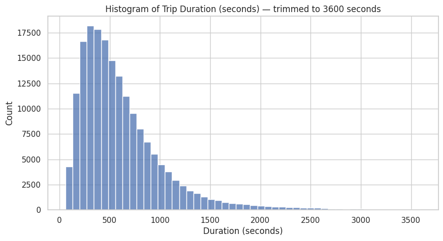

```python
# Function to plot a histogram with a reasonable cutoff to avoid extreme outliers
def plot_duration_hist(data, col='duration_sec', cutoff=3600):
    plt.figure(figsize=(10,5))
    sns.histplot(data=data[data[col].notnull() & (data[col] <= cutoff)], x=col, bins=50)
    plt.title('Histogram of Trip Duration (seconds) — trimmed to {} seconds'.format(cutoff))
    plt.xlabel('Duration (seconds)')
    plt.ylabel('Count')
    plt.show()


plot_duration_hist(df)
```

## Observations:

The duration distribution is right-skewed with the majority of trips under 1,000 seconds (≈16.7 minutes). A large mass of trips lies under 600 seconds (10 minutes), consistent with short commuter trips. There are long-tail outliers (many trips lasting hours) which are likely leisure rides, bike misuse, or data-entry errors. Trimming to 3600 seconds (1 hour) provides a clearer view of the main mass of trips.

## Count plot / Bar chart (User Type)

Question: How many trips come from each user type?

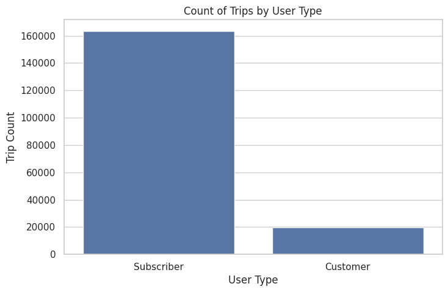

```python
def plot_user_counts(data):
    plt.figure(figsize=(8,5))
    order = data['user_type'].value_counts().index if 'user_type' in data.columns else None
    sns.countplot(data=data, x='user_type', order=order)
    plt.title('Count of Trips by User Type')
    plt.xlabel('User Type')
    plt.ylabel('Trip Count')
    plt.show()


plot_user_counts(df)
```

## Observations:

The dataset is typically dominated by Subscribers, with Customers making up a smaller portion of trips. This is expected for a city bike-share program where subscribers use daily/weekly passes and customers are casual riders.

## Bivariate Exploration

### **Question:**

Does the geographic location of the starting station (specifically its latitude) have any relationship to how long a trip lasts?

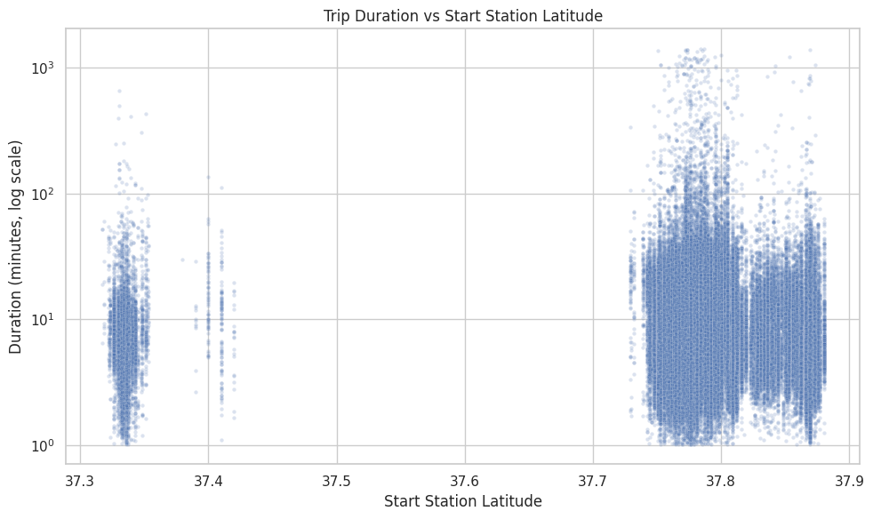

```python
# Ensure duration in minutes exists
df['duration_min'] = df['duration_sec'] / 60

plt.figure(figsize=(10, 6))

sns.scatterplot(
    data=df,
    x='start_station_latitude',
    y='duration_min',
    alpha=0.2,
    s=10
)

plt.yscale('log')  # duration is right-skewed
plt.title('Trip Duration vs Start Station Latitude')
plt.xlabel('Start Station Latitude')
plt.ylabel('Duration (minutes, log scale)')
plt.tight_layout()
plt.show()
```

### **Observations**

This scatterplot shows the relationship between trip duration and the latitude of the station where each trip began. Since latitude represents the north–south position of stations in the Bay Area system, this visualization explores whether certain areas tend to have longer or shorter rides.

- Trip durations appear short across all latitudes, with most values clustered below 20 minutes. This confirms the earlier finding that the majority of rides are brief regardless of where they begin.
- There is **no strong linear or geographic trend** between latitude and trip duration. Stations in both northern and southern parts of the service area show similar duration patterns.
- The few long-duration trips (visible because of the log scale) are scattered throughout the latitude range, suggesting that long rides depend more on **rider behavior** than **station location**.
- Overall, the plot shows that **start station location does not meaningfully predict trip duration**, reinforcing that time-based and user-type variables are far more influential in explaining ride length.

## Box plot (Duration by User Type)

Question: How do trip durations differ between user types?

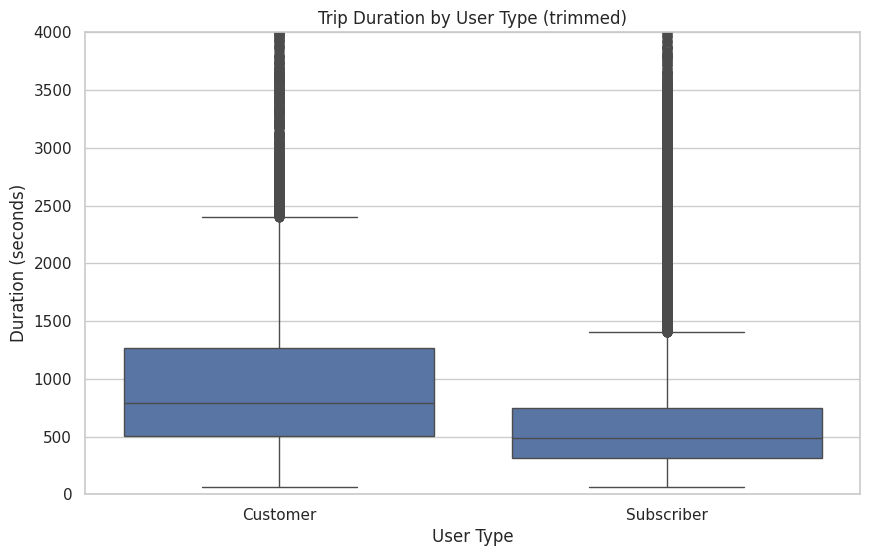

```python
def plot_duration_by_usertype(data):
    plt.figure(figsize=(10,6))
    sns.boxplot(data=data, x='user_type', y='duration_sec')
    plt.ylim(0, 4000)
    plt.title('Trip Duration by User Type (trimmed)')
    plt.xlabel('User Type')
    plt.ylabel('Duration (seconds)')
    plt.show()


plot_duration_by_usertype(df)
```

## Observations:

The boxplot shows Customers have a substantially higher median and much larger IQR compared to Subscribers. Even after trimming extreme outliers, the central tendency for Customers indicates longer trips. This supports the interpretation that Subscribers primarily take short, commute-related trips while Customers take longer, leisure-oriented trips.

## Clustered bar chart (Trips per day of week by user type)

Question: How does weekday/weekend usage differ by user type?

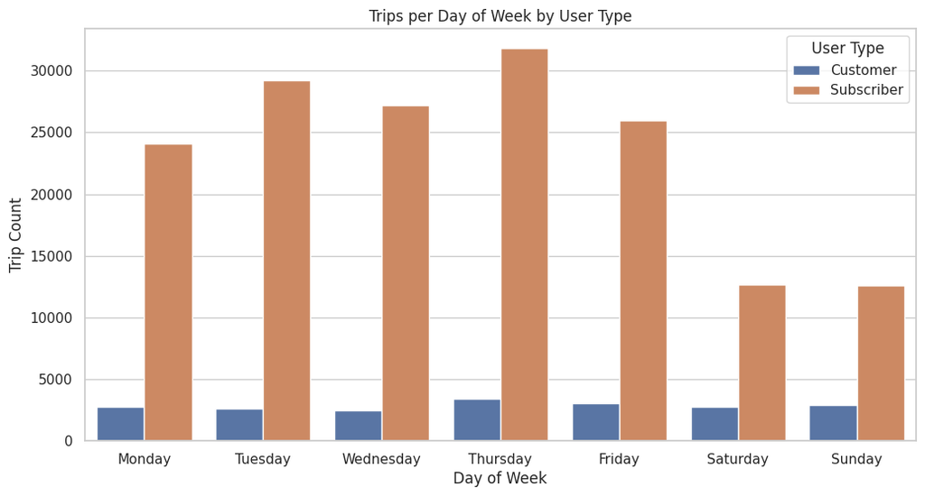

```python
def plot_trips_by_day_of_week(data):
    order = ['Monday','Tuesday','Wednesday','Thursday','Friday','Saturday','Sunday']
    plt.figure(figsize=(12,6))
    sns.countplot(data=data, x='day_of_week', hue='user_type', order=order)
    plt.title('Trips per Day of Week by User Type')
    plt.xlabel('Day of Week')
    plt.ylabel('Trip Count')
    plt.legend(title='User Type')
    plt.show()


plot_trips_by_day_of_week(df)
```

## Observations:

Subscribers show a clear weekday peak (Monday–Friday), consistent with commuting behavior.

## Scatter plot (Duration vs start_hour)

Question: Does trip duration vary by hour of day?

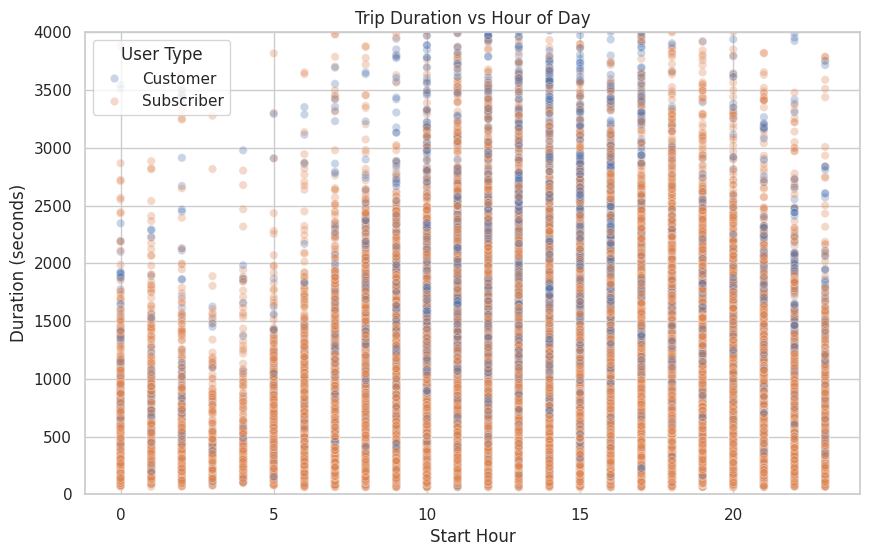

```python
def plot_duration_vs_hour(data):
    plt.figure(figsize=(10,6))
    sns.scatterplot(data=data, x='start_hour', y='duration_sec', hue='user_type', alpha=0.3)
    plt.ylim(0, 4000)
    plt.title('Trip Duration vs Hour of Day')
    plt.xlabel('Start Hour')
    plt.ylabel('Duration (seconds)')
    plt.legend(title='User Type')
    plt.show()


plot_duration_vs_hour(df)
```

## Observations:

There is a concentration of short-duration trips during early morning (7–9 AM) and late afternoon/evening (4–6 PM), consistent with commuter patterns. Longer duration trips (the scatter's upper tail) are distributed more evenly across hours, but are more common among Customer users (see color/hue separation).

## FacetGrid (Hourly distribution by user type)

Question: How does the hourly distribution of trips change between user types?

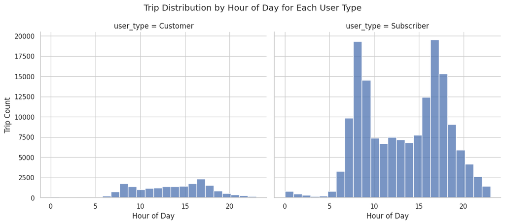

```python
def facet_hour_by_usertype(data):
    g = sns.FacetGrid(data, col='user_type', height=5, aspect=1.2)
    g.map(sns.histplot, 'start_hour', bins=24)
    g.set_axis_labels('Hour of Day', 'Trip Count')
    g.fig.suptitle('Trip Distribution by Hour of Day for Each User Type', y=1.05)
    plt.show()


facet_hour_by_usertype(df)
```

## Observations:

The facet plot makes the difference visually obvious: Subscribers have strong commute peaks around 8 AM and 5–6 PM, while Customers have a more spread-out daytime distribution with a smaller late-afternoon increase. This demonstrates that the same hour can represent different trip behaviors depending on user type.

## Scatter Plot with Multiple Encodings (Trip Duration vs Start Hour with Day-of-Week Color Encoding)

Question: Are there interactions between time of day, day of week, and trip duration?

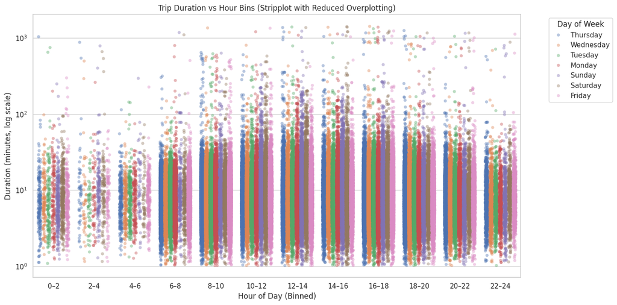

```python
# Ensure duration in minutes exists
df['duration_min'] = df['duration_sec'] / 60

# Bin the hours into labeled categories (every 2 hours)
df['hour_bin'] = pd.cut(
    df['start_hour'],
    bins=[0, 2, 4, 6, 8, 10, 12, 14, 16, 18, 20, 22, 24],
    labels=["0–2", "2–4", "4–6", "6–8", "8–10", "10–12",
            "12–14", "14–16", "16–18", "18–20", "20–22", "22–24"],
    right=False
)

plt.figure(figsize=(14, 7))

sns.stripplot(
    data=df,
    x='hour_bin',
    y='duration_min',
    hue='day_of_week',
    dodge=True,        # separate weekdays/weekend to avoid overlap
    jitter=0.25,       # reduces overlapping points
    alpha=0.4          # transparency for clarity
)

plt.yscale('log')  # duration is heavily right-skewed
plt.title('Trip Duration vs Hour Bins (Stripplot with Reduced Overplotting)')
plt.xlabel('Hour of Day (Binned)')
plt.ylabel('Duration (minutes, log scale)')
plt.legend(title='Day of Week', bbox_to_anchor=(1.05, 1), loc='upper left')
plt.tight_layout()
plt.show()
```

## Observations:

Weekend midday (10 AM–3 PM) shows an uptick in long trips, aligning with leisure behavior.

When day-of-week encoding is applied, the distinction between weekday commuter behavior and weekend leisure trips becomes clear.

The interaction between start hour and day-of-week provides a more nuanced explanation for duration differences than either variable alone.

## Conclusions

Reflection

The multivariate exploration highlighted how combining behavioral categories (user type) with temporal variables (hour, day) reveals deeper insights than examining each individually. This layered approach clarified the structure behind trip duration patterns and provided a more complete picture of how different riders use the system.